# Lab 5 assignment - Point pattern analysis

```r
rm(list=ls())

require(spatstat)
require(tidyverse)
require(terra)
```

# Challenge 1 (3 points)

Create a simulation window on a landscape stretching from 0 to 100 units in both the x and y directions. Now simulate the distribution of an organism on this landscape using a Poisson process with a lambda value of 0.01. Plot this organism’s distribution.

```r
set.seed(75)

Window = owin(xrange = c(0, 100), yrange = c(0, 100))

simO = rpoispp(lambda = (0.01), nsim=1, win=Window)
plot(simO)

summary(simO)
```

```
## Planar point pattern:  92 points
## Average intensity 0.0092 points per square unit
##
## Coordinates are given to 6 decimal places
##
## Window: rectangle = [0, 100] x [0, 100] units
## Window area = 10000 square units
```

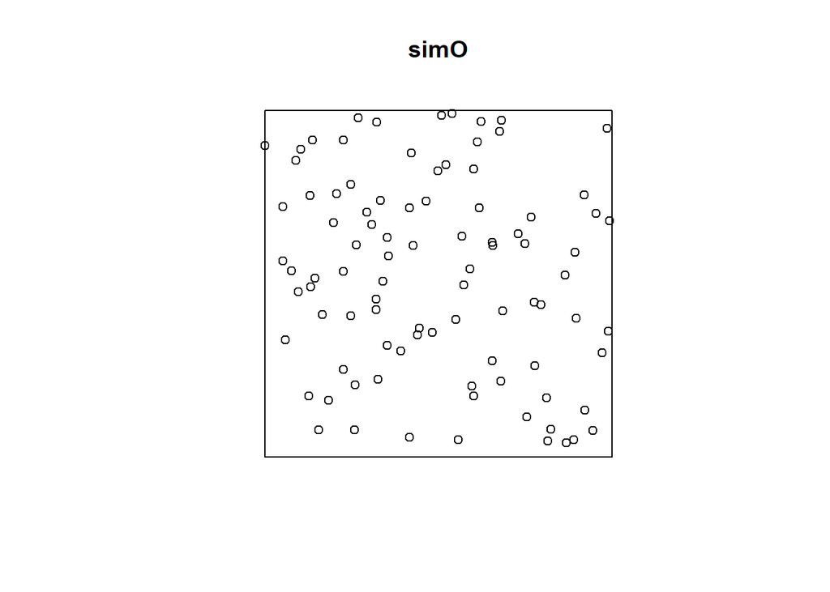

```r
q = quadratcount(simO, nx=4, ny=4)
plot(simO)
```

[figure not shown]

```r
plot(q)
```

```r
quadrat.test(simO, nx=4, ny=4, method='Chisq')
```

```
##
##  Chi-squared test of CSR using quadrat counts
##
## data:  simO
## X2 = 12.348, df = 15, p-value = 0.6949
## alternative hypothesis: two.sided
##
## Quadrats: 4 by 4 grid of tiles
```

```r
lCsr = envelope(simO, Lest, nsim=99, rank=1, correction='translate', global=F)
```

```
## Generating 99 simulations of CSR  ...
## 1, 2, 3, 4, 5, 6, 7, 8, 9, 10, 11, 12, 13, 14, 15, 16, 17, 18, 19, 20,
## 21, 22, 23, 24, 25, 26, 27, 28, 29, 30, 31, 32, 33, 34, 35, 36, 37, 38, 39, 40,
## 41, 42, 43, 44, 45, 46, 47, 48, 49, 50, 51, 52, 53, 54, 55, 56, 57, 58, 59, 60,
## 61, 62, 63, 64, 65, 66, 67, 68, 69, 70, 71, 72, 73, 74, 75, 76, 77, 78, 79, 80,
## 81, 82, 83, 84, 85, 86, 87, 88, 89, 90, 91, 92, 93, 94, 95, 96, 97, 98,
## 99.
##
## Done.
```

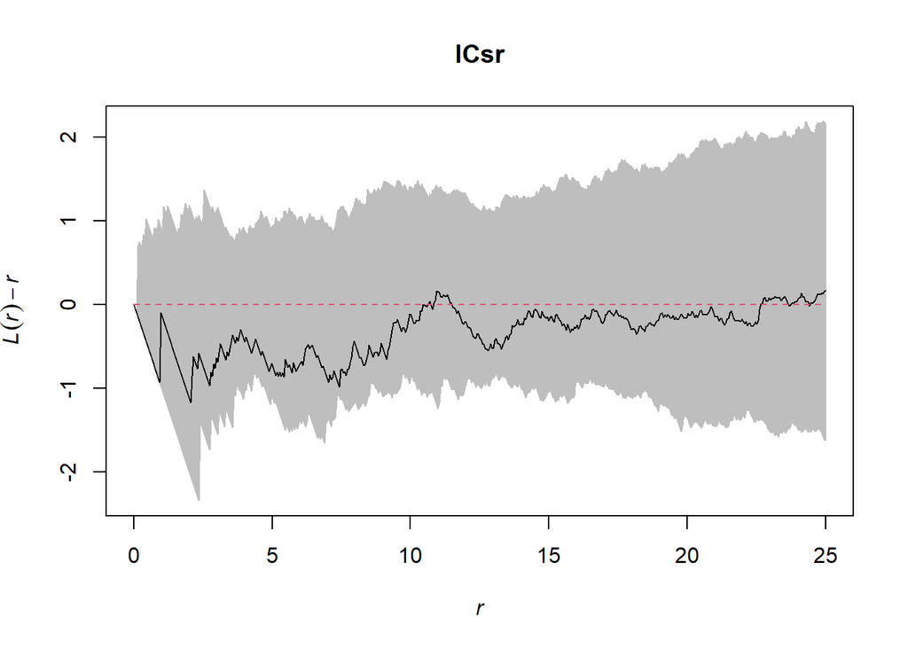

```r
plot(lCsr, .-r~r, shade=c('hi', 'lo'), legend=F)
```

**How many organisms are there on your landscape?** 92 organisms **What is the expected number of organisms that you should find on this landscape based on your simulation parameters? Why?** 10,000 x 0.01 = 100 expected organisms. Using the Poisson process, the expected number of organisms within an area is equal to the product of the lambda (0.01) and the area of the window (100 x 100).

# Challenge 2 (3 points)

Verify that there no linear or quadratic pattern in the distribution of your organisms using fitted Poisson process models. Show the outcome of this analysis.

```r
ppInt = ppm(simO, ~1)
ppXy = ppm(simO, ~ x + y)
ppXy2 = ppm(simO, ~polynom (x, y, 2))

data.frame(model = c('int', 'xy', 'xy2'),
           AIC = c(AIC(ppInt), AIC(ppXy), AIC(ppXy2)))
```

| model | AIC |
| --- | --- |
| int | 1048.694 |
| xy | 1051.817 |
| xy2 | 1054.004 |

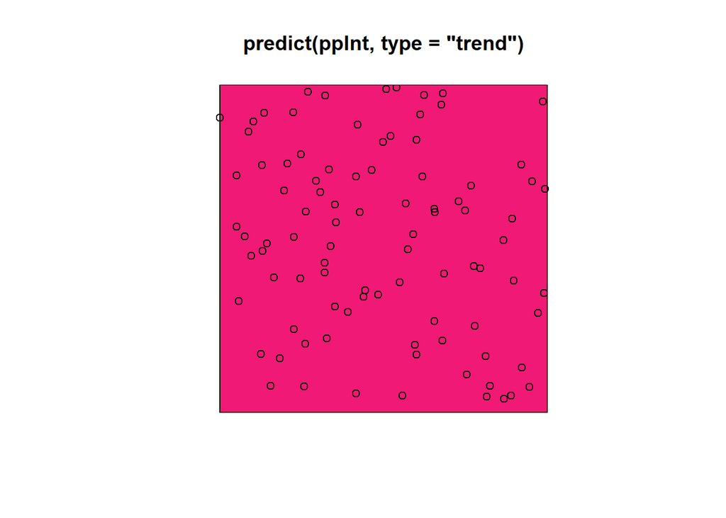

```r
plot(predict(ppInt, type='trend'))
plot(simO, add=T)
```

**Explain your conclusion.** I calculated the AIC value for my three models: The first assumes a homogeneous point process, the second assumes the intensity is a linear function of x and y coordinates, and the third assumes that there is a quadratic trend in the distribution. The model with the intercept-only (int) has the lowest AIC value (1048.694), the model with linear terms has a slightly higher AIC value (1051.817), and the model with quadratic terms has the highest AIC value (1054.004). The intercept-only model has the lowest AIC, suggesting that there is no significant linear or quadratic pattern in the distribution of the organisms. The same is suggested by the trend plot of the fitted model with just the intercept.

# Challenge 3 (14 points)

I have simulated the distributions of 2 critters and provided their x-y coordinates. One of them is a non-territorial predator. The second is a critter that is preyed upon by the predator and exhibits a fear response to the predator’s presence. Use the tools you learned in the lab to explore the distributions of these two critters. Identify which one is the predator and which is the prey, and provide code and a thorough justification supporting your conclusion.

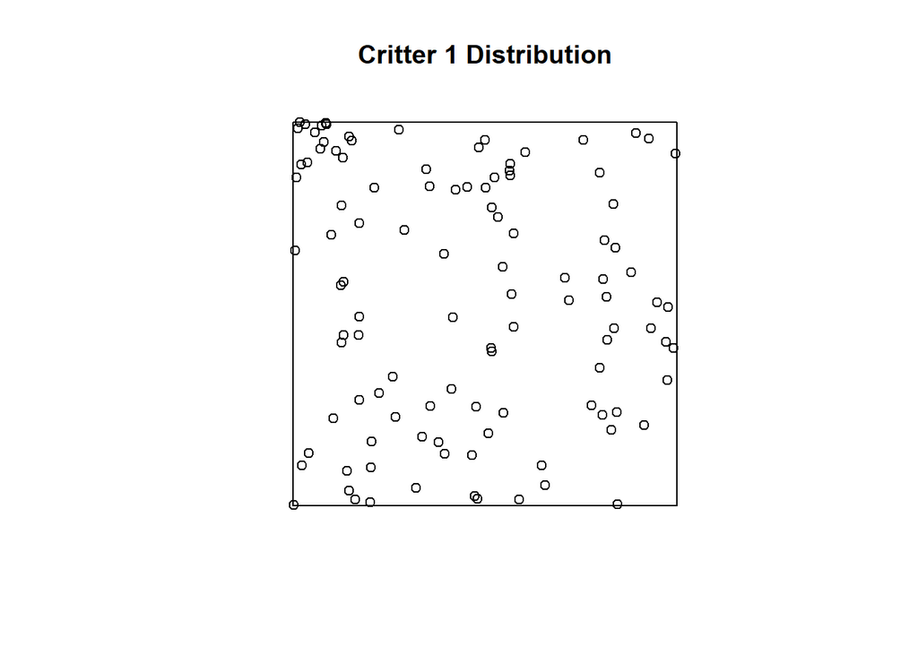

```r
predPreyWin = owin(xrange = c(0, 100), yrange = c(0, 100))

critter1 = read.csv('https://raw.githubusercontent.com/ValenteJJ/SpatialEcology/main/Week5/species1.csv') %>%
  mutate(org = 'critter1')
pppC1 = ppp(x=critter1$x, y=critter1$y, window = predPreyWin)
plot(pppC1, main= "Critter 1 Distribution")
```

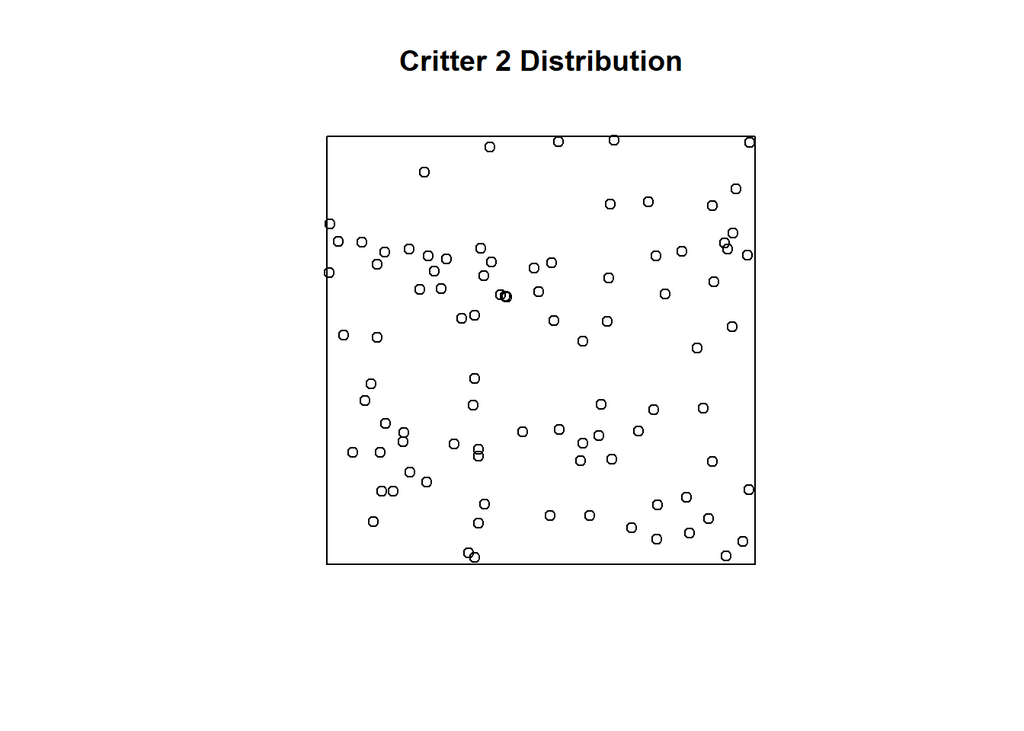

```r
critter2 = read.csv('https://raw.githubusercontent.com/ValenteJJ/SpatialEcology/main/Week5/species2.csv') %>%
  mutate(org = 'critter2')
pppC2 = ppp(x=critter2$x, y=critter2$y, window = predPreyWin)
plot(pppC2, main= "Critter 2 Distribution")
```

```r
summary(pppC1)
```

```
## Planar point pattern:  108 points
## Average intensity 0.0108 points per square unit
##
## Coordinates are given to 6 decimal places
##
## Window: rectangle = [0, 100] x [0, 100] units
## Window area = 10000 square units
```

```r
summary(pppC2)
```

```
## Planar point pattern:  91 points
## Average intensity 0.0091 points per square unit
##
## Coordinates are given to 6 decimal places
##
## Window: rectangle = [0, 100] x [0, 100] units
## Window area = 10000 square units
```

### Pair correlation function (g function)

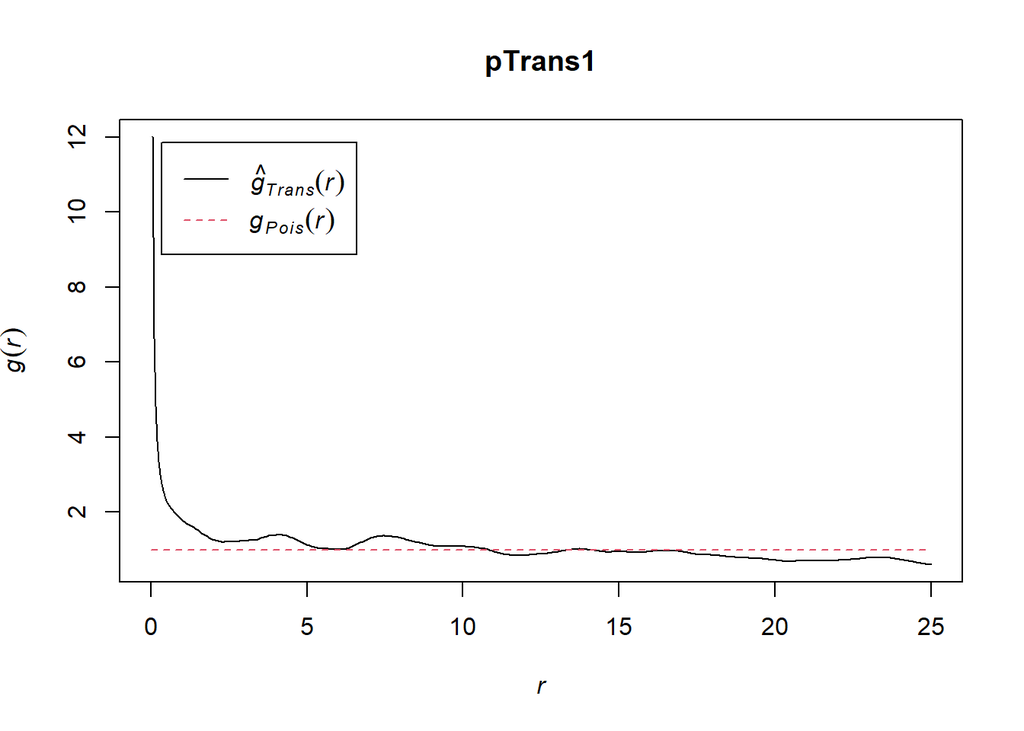

```r
pTrans1 = pcf(pppC1, correction='translate', stoyan=0.15)
plot(pTrans1)
```

```r
pEnv1 = envelope(pppC1, pcf, nsim=99, rank=1, correction='translate', global=F)
```

```
## Generating 99 simulations of CSR  ...
## 1, 2, 3, 4, 5, 6, 7, 8, 9, 10, 11, 12, 13, 14, 15, 16, 17, 18, 19, 20,
## 21, 22, 23, 24, 25, 26, 27, 28, 29, 30, 31, 32, 33, 34, 35, 36, 37, 38, 39, 40,
## 41, 42, 43, 44, 45, 46, 47, 48, 49, 50, 51, 52, 53, 54, 55, 56, 57, 58, 59, 60,
## 61, 62, 63, 64, 65, 66, 67, 68, 69, 70, 71, 72, 73, 74, 75, 76, 77, 78, 79, 80,
## 81, 82, 83, 84, 85, 86, 87, 88, 89, 90, 91, 92, 93, 94, 95, 96, 97, 98,
## 99.
##
## Done.
```

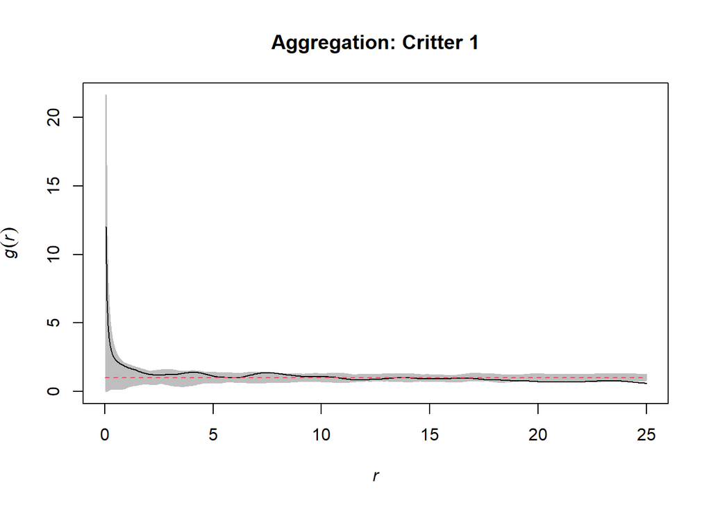

```r
plot(pEnv1, shade=c('hi', 'lo'), legend=F, main = "Aggregation: Critter 1")
```

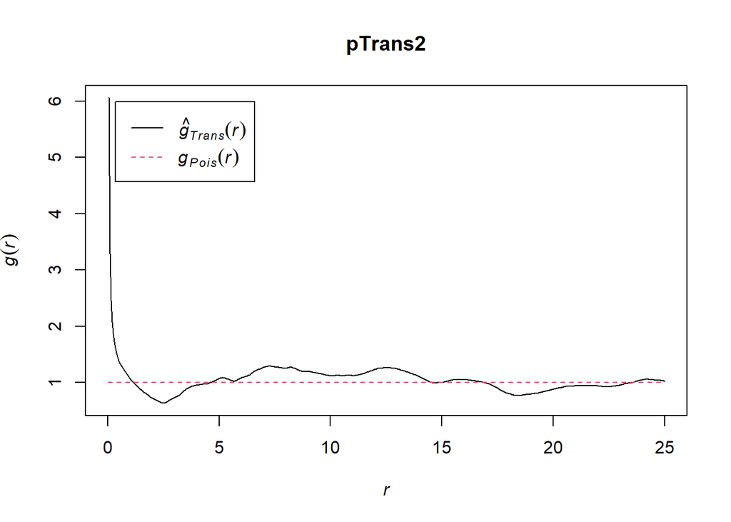

```r
pTrans2 = pcf(pppC2, correction='translate', stoyan=0.15)
plot(pTrans2)
```

```r
pEnv2 = envelope(pppC2, pcf, nsim=99, rank=1, correction='translate', global=F)
```

```
## Generating 99 simulations of CSR  ...
## 1, 2, 3, 4, 5, 6, 7, 8, 9, 10, 11, 12, 13, 14, 15, 16, 17, 18, 19, 20,
## 21, 22, 23, 24, 25, 26, 27, 28, 29, 30, 31, 32, 33, 34, 35, 36, 37, 38, 39, 40,
## 41, 42, 43, 44, 45, 46, 47, 48, 49, 50, 51, 52, 53, 54, 55, 56, 57, 58, 59, 60,
## 61, 62, 63, 64, 65, 66, 67, 68, 69, 70, 71, 72, 73, 74, 75, 76, 77, 78, 79, 80,
## 81, 82, 83, 84, 85, 86, 87, 88, 89, 90, 91, 92, 93, 94, 95, 96, 97, 98,
## 99.
##
## Done.
```

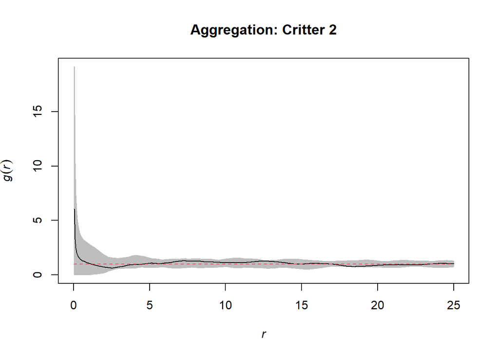

```r
plot(pEnv2, shade=c('hi', 'lo'), legend=F, main = "Aggregation: Critter 2")
```

### # G-function: nearest neighbors

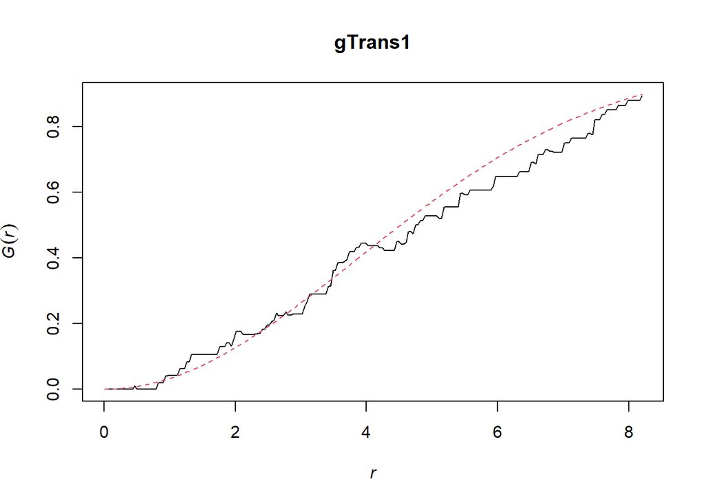

```r
gTrans1 = Gest(pppC1, correction='rs')
plot(gTrans1, legend=F)
```

```r
gEnv1 = envelope(pppC1, Gest, nsim=99, rank=1, correction='rs', global=F)
```

```
## Generating 99 simulations of CSR  ...
## 1, 2, 3, 4, 5, 6, 7, 8, 9, 10, 11, 12, 13, 14, 15, 16, 17, 18, 19, 20,
## 21, 22, 23, 24, 25, 26, 27, 28, 29, 30, 31, 32, 33, 34, 35, 36, 37, 38, 39, 40,
## 41, 42, 43, 44, 45, 46, 47, 48, 49, 50, 51, 52, 53, 54, 55, 56, 57, 58, 59, 60,
## 61, 62, 63, 64, 65, 66, 67, 68, 69, 70, 71, 72, 73, 74, 75, 76, 77, 78, 79, 80,
## 81, 82, 83, 84, 85, 86, 87, 88, 89, 90, 91, 92, 93, 94, 95, 96, 97, 98,
## 99.
##
## Done.
```

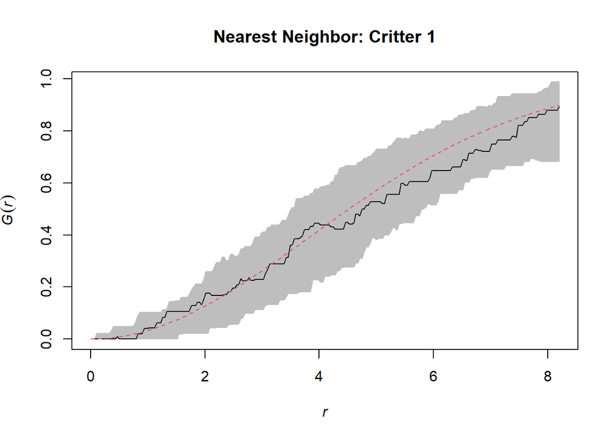

```r
plot(gEnv1, shade=c('hi', 'lo'), legend=F, main = "Nearest Neighbor: Critter 1")
```

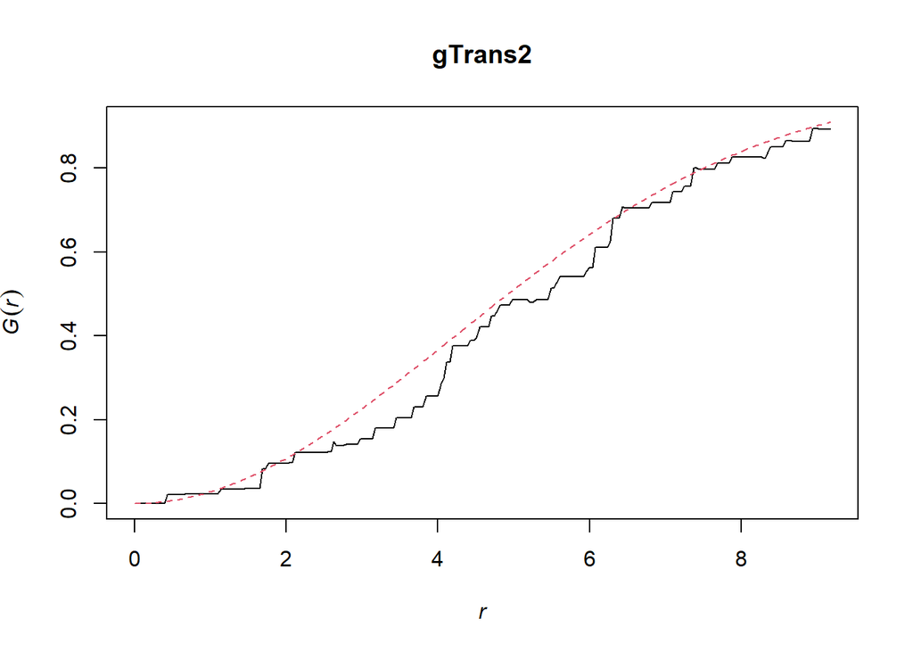

```r
gTrans2 = Gest(pppC2, correction='rs')
plot(gTrans2, legend=F)
```

```r
gEnv2 = envelope(pppC2, Gest, nsim=99, rank=1, correction='rs', global=F)
```

```
## Generating 99 simulations of CSR  ...
## 1, 2, 3, 4, 5, 6, 7, 8, 9, 10, 11, 12, 13, 14, 15, 16, 17, 18, 19, 20,
## 21, 22, 23, 24, 25, 26, 27, 28, 29, 30, 31, 32, 33, 34, 35, 36, 37, 38, 39, 40,
## 41, 42, 43, 44, 45, 46, 47, 48, 49, 50, 51, 52, 53, 54, 55, 56, 57, 58, 59, 60,
## 61, 62, 63, 64, 65, 66, 67, 68, 69, 70, 71, 72, 73, 74, 75, 76, 77, 78, 79, 80,
## 81, 82, 83, 84, 85, 86, 87, 88, 89, 90, 91, 92, 93, 94, 95, 96, 97, 98,
## 99.
##
## Done.
```

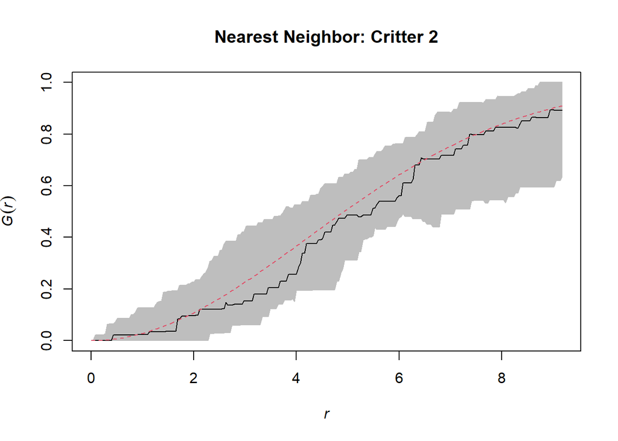

```r
plot(gEnv2, shade=c('hi', 'lo'), legend=F, main = "Nearest Neighbor: Critter 2")
```

### Individual Distribution - Ripley’s K

```r
lPresent1 = envelope(pppC1, Lest, nsim=99, rank=1, i='critter1', global=F)
```

```
## Generating 99 simulations of CSR  ...
## 1, 2, 3, 4, 5, 6, 7, 8, 9, 10, 11, 12, 13, 14, 15, 16, 17, 18, 19, 20,
## 21, 22, 23, 24, 25, 26, 27, 28, 29, 30, 31, 32, 33, 34, 35, 36, 37, 38, 39, 40,
## 41, 42, 43, 44, 45, 46, 47, 48, 49, 50, 51, 52, 53, 54, 55, 56, 57, 58, 59, 60,
## 61, 62, 63, 64, 65, 66, 67, 68, 69, 70, 71, 72, 73, 74, 75, 76, 77, 78, 79, 80,
## 81, 82, 83, 84, 85, 86, 87, 88, 89, 90, 91, 92, 93, 94, 95, 96, 97, 98,
## 99.
##
## Done.
```

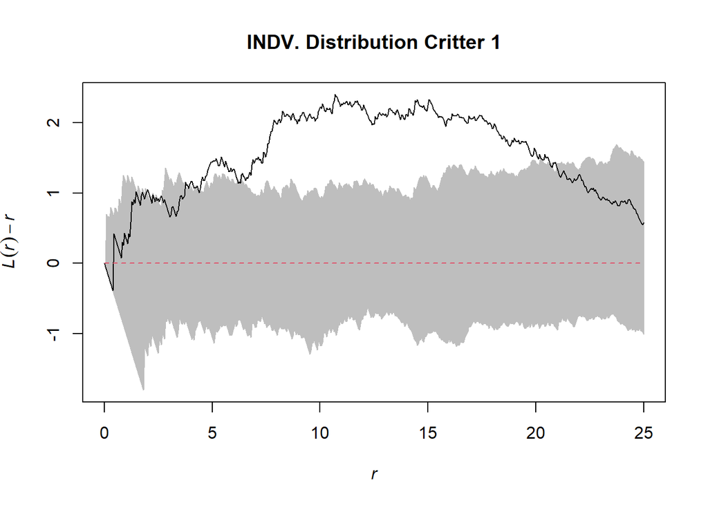

```r
plot(lPresent1, .-r~r, legend=F, main = "INDV. Distribution Critter 1")
```

```r
lPresent2 = envelope(pppC2, Lest, nsim=99, rank=1, i='critter2', global=F)
```

```
## Generating 99 simulations of CSR  ...
## 1, 2, 3, 4, 5, 6, 7, 8, 9, 10, 11, 12, 13, 14, 15, 16, 17, 18, 19, 20,
## 21, 22, 23, 24, 25, 26, 27, 28, 29, 30, 31, 32, 33, 34, 35, 36, 37, 38, 39, 40,
## 41, 42, 43, 44, 45, 46, 47, 48, 49, 50, 51, 52, 53, 54, 55, 56, 57, 58, 59, 60,
## 61, 62, 63, 64, 65, 66, 67, 68, 69, 70, 71, 72, 73, 74, 75, 76, 77, 78, 79, 80,
## 81, 82, 83, 84, 85, 86, 87, 88, 89, 90, 91, 92, 93, 94, 95, 96, 97, 98,
## 99.
##
## Done.
```

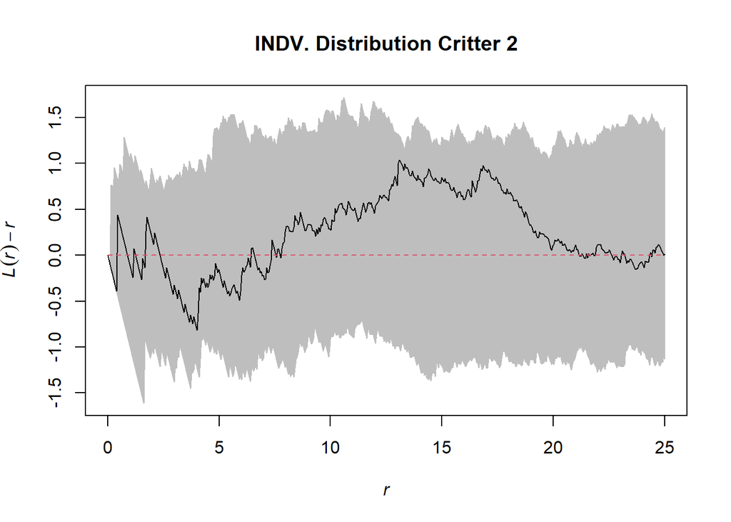

```r
plot(lPresent2, .-r~r, legend=F, main = "INDV. Distribution Critter 2")
```

### Conditional Distribution

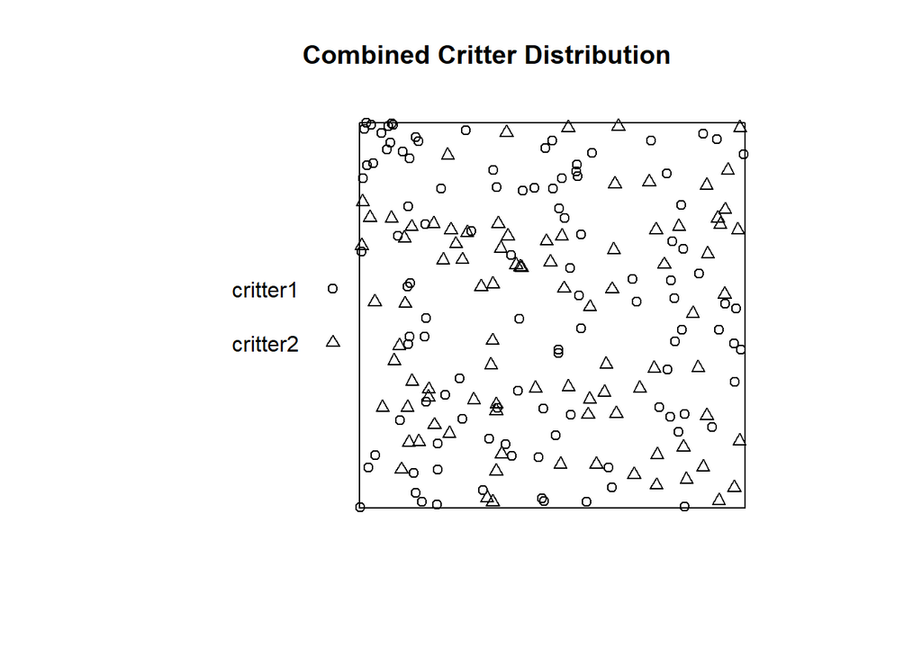

```r
cppp = rbind(critter1, critter2)
pppc = ppp(x = cppp$x, y = cppp$y, marks = factor(cppp$org), window = predPreyWin)
plot(pppc, main = "Combined Critter Distribution")
```

```r
lMultiCritter2 = envelope(pppc, Lcross, nsim = 99, rank = 1, i = 'critter2', j = 'critter1', simulate = expression(rlabel(pppc)))
```

```
## Generating 99 simulations by evaluating expression  ...
## 1, 2, 3, 4, 5, 6, 7, 8, 9, 10, 11, 12, 13, 14, 15, 16, 17, 18, 19, 20,
## 21, 22, 23, 24, 25, 26, 27, 28, 29, 30, 31, 32, 33, 34, 35, 36, 37, 38, 39, 40,
## 41, 42, 43, 44, 45, 46, 47, 48, 49, 50, 51, 52, 53, 54, 55, 56, 57, 58, 59, 60,
## 61, 62, 63, 64, 65, 66, 67, 68, 69, 70, 71, 72, 73, 74, 75, 76, 77, 78, 79, 80,
## 81, 82, 83, 84, 85, 86, 87, 88, 89, 90, 91, 92, 93, 94, 95, 96, 97, 98,
## 99.
##
## Done.
```

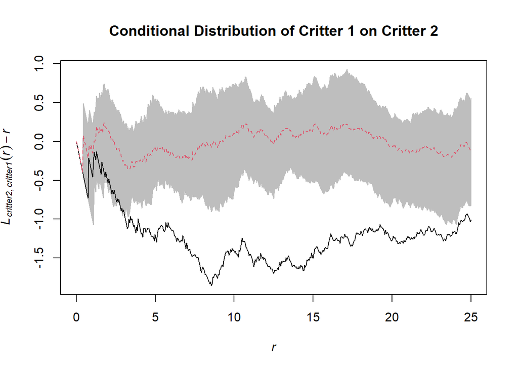

```r
plot(lMultiCritter2, . - r ~ r, legend = FALSE, main = "Conditional Distribution of Critter 1 on Critter 2")
```

```r
lMultiCritter1 = envelope(pppc, Lcross, nsim = 99, rank = 1, i = 'critter1', j = 'critter2', simulate = expression(rlabel(pppc)))
```

```
## Generating 99 simulations by evaluating expression  ...
## 1, 2, 3, 4, 5, 6, 7, 8, 9, 10, 11, 12, 13, 14, 15, 16, 17, 18, 19, 20,
## 21, 22, 23, 24, 25, 26, 27, 28, 29, 30, 31, 32, 33, 34, 35, 36, 37, 38, 39, 40,
## 41, 42, 43, 44, 45, 46, 47, 48, 49, 50, 51, 52, 53, 54, 55, 56, 57, 58, 59, 60,
## 61, 62, 63, 64, 65, 66, 67, 68, 69, 70, 71, 72, 73, 74, 75, 76, 77, 78, 79, 80,
## 81, 82, 83, 84, 85, 86, 87, 88, 89, 90, 91, 92, 93, 94, 95, 96, 97, 98,
## 99.
##
## Done.
```

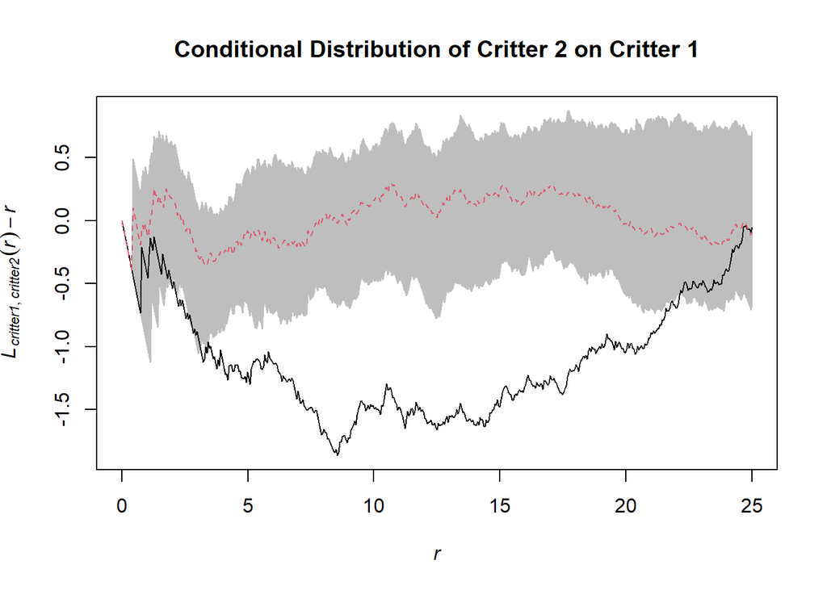

```r
plot(lMultiCritter1, . - r ~ r, legend = FALSE, main = "Conditional Distribution of Critter 2 on Critter 1")
```